# Analysis of interprovincial flow network of Chinese labor population

Zheran Pan

2024-11-02

## Research question

The cross-region flow of labor widely exist in regions of developing country. As a populous country, along with uneven regional development, China has a higher frequency of this phenomenon, making it a popular studying topic. However, the previous studies often focus on the static display of the spatial distribution of labor force, and present the flowing trend of labor force by showing the distribution pattern of different time nodes, for example, Xianghua Lin(2003) studied the changes of the labor force spatial distribution in the region of Guangdong province from 1990 to 2000. Although this method can obtain the flow direction of labor population through comparing the distribution patterns of different time nodes, but can hardly do further research in the characteristics of different regions’ labor migration inside the studying area. Xingchen Liu(2024), has set a great example of constructing a population flow network using data from China Migrants Dynamic Survey, and analyzing it to obtain the characteristics of China’s population migration. Therefore, this paper put its focus on studying working-age migrating people. By constructing a migration network, it will explore the characteristics of inter-provincial labor migration in China.

## Data source

This article is based on the data from China Migrants Dynamic Survey(CMDS) in 2017,which is available after applying [online](https://www.chinaldrk.org.cn/wjw/#/home). CMDS takes the floating population annual report database of 31 provinces and the Xinjiang Production and Construction Corps as the base sampling frame and conducts samples by using a stratified, multi-stage, scale-proportional PPS approach. The respondents of CMDS is inflow population aged 15 and above who have lived in the inflow area for one month or more, and are not registered in the district.

In this paper, the registered residence of floating population is regarded as the place moved out from, and the current place of residence is regarded as the relocation place. The labor force is defined as Chinese citizens between the ages of 15 and 64.

CMDS contains the individual weights of each sample unit, which is a standardized result from multiplying the design weights, the no-answered weights, and the post-adjustment weights. The proportion of samples allocated between the layers is inconsistent with their proportion in the whole, so it is necessary to assign design weights between the layers to make the final sample ratio consistent with the proportion of the population. In the actual survey, it is necessary to perform no-answer weighting in cases where the amount of survey tasks cannot be completed after substitution, or if the survey object is not met and the data is cleared during the data cleaning stage.

## Mapping inter-provincial population mobility networks

**Install and load packages**

The below code checks if required packages are installed. If not, use `install.packages("package.name")` to install the missing packages.

```r
library(igraph)
library(knitr)
library(corrplot)
library(tidyverse)
library(geojsonio)
library(stplanr)
library(leaflet)
library(rprojroot)
library(kableExtra)
library(sf)
library(dplyr)
library(rmapshaper)
library(ggplot2)

knitr::opts_chunk$set(echo = TRUE)

path <- find_rstudio_root_file()
```

**Read and filter raw data**

Save the 2017 CMDS data in csv format on your working directory under the `/data` directory. Read and load the .csv with following code.

```r
path.data <- paste0(path, "/data/2017-A.csv")
rawdata <- read_csv(path.data)
glimpse(rawdata)
```

```
## Rows: 169,989
## Columns: 387
## $ newID    <dbl> 1, 2, 3, 4, 5, 6, 7, 8, 9, 10, 11, 12, 13, 14, 15, 16, 17, 18…
## $ C1       <chr> "北京市", "北京市", "北京市", "北京市", "北京市", "北京市", "…
## $ C2       <chr> "北京市", "北京市", "北京市", "北京市", "北京市", "北京市", "…
## $ C3       <chr> "东城区", "东城区", "东城区", "东城区", "东城区", "东城区", "…
## $ C6       <dbl> 1, 1, 1, 1, 1, 1, 1, 1, 1, 1, 1, 1, 1, 1, 1, 1, 1, 1, 1, 1, 2…
## $ C7       <dbl> 1, 1, 1, 1, 1, 1, 1, 1, 1, 1, 1, 1, 1, 1, 1, 1, 1, 1, 1, 1, 1…
## $ C14      <dbl> 1, 1, 1, 1, 1, 1, 1, 1, 1, 1, 1, 1, 1, 1, 1, 1, 1, 1, 1, 1, 2…
## $ Q100     <dbl> 4, 3, 3, 3, 2, 5, 3, 3, 4, 2, 3, 3, 3, 3, 3, 2, 4, 4, 6, 3, 5…
## $ q101id1  <dbl> 1, 1, 1, 1, 1, 1, 1, 1, 1, 1, 1, 1, 1, 1, 1, 1, 1, 1, 1, 1, 1…
## $ q101a1   <dbl> 1, 1, 1, 1, 1, 1, 1, 1, 1, 1, 1, 1, 1, 1, 1, 1, 1, 1, 1, 1, 1…
## $ q101b1   <dbl> 2, 1, 2, 2, 1, 1, 2, 1, 2, 2, 2, 2, 1, 1, 1, 2, 2, 1, 2, 1, 2…
## $ q101c1y  <dbl> 1956, 1970, 1966, 1980, 1965, 1949, 1984, 1990, 1974, 1969, 1…
## $ q101c1m  <dbl> 12, 6, 1, 10, 2, 5, 7, 1, 1, 3, 6, 12, 4, 1, 12, 10, 4, 2, 7,…
```

[output cut: 374 more lines]

By querying the supporting variable file `/data/2017-A-stata.dta`, we can know that:

- C1 = Province of current residence
- q101c1y = Year of birth
- q101l1 = Flow Range
- q101j1b = Province of registered residence
- w_l = Individual standardized weights

As these columns represent the variables we will use for filtering and drawing the population flow network, I extract them and construct a new object.

```r
data_screen0 <- rawdata %>%
  select(`C1`, `q101j1b`, `q101l1`, `q101c1y`,`w_l`) %>%
  rename(current_province = `C1`, register_province = `q101j1b`, birth_year = `q101c1y`, flow_range = `q101l1`, weight = `w_l`)
glimpse(data_screen0)
```

```
## Rows: 169,989
## Columns: 5
## $ current_province  <chr> "北京市", "北京市", "北京市", "北京市", "北京市", "…
## $ register_province <chr> "山东省", "河北省", "山东省", "吉林省", "江苏省", "…
## $ flow_range        <dbl> 1, 1, 1, 1, 1, 1, 1, 1, 1, 1, 1, 1, 1, 1, 1, 1, 1, 1…
## $ birth_year        <dbl> 1956, 1970, 1966, 1980, 1965, 1949, 1984, 1990, 1974…
## $ weight            <dbl> 1.948622, 1.475701, 1.948622, 1.585694, 1.667071, 1.…
```

In the columns `current_province` and `register_province`, we need to convert the Chinese province name into English. It should be noted that the Xinjiang Production and Construction Corps and the Xinjiang Uyghur Autonomous Region are parallel administrative regions, but geographically they both belong to Xinjiang, so they need to be merged.

```r
data_screen0$current_province <- gsub("北京市", "beijing", data_screen0$current_province)
data_screen0$current_province <- gsub("安徽省", "anhui", data_screen0$current_province)
data_screen0$current_province <- gsub("福建省", "fujian", data_screen0$current_province)
data_screen0$current_province <- gsub("甘肃省", "gansu", data_screen0$current_province)
data_screen0$current_province <- gsub("广东省", "guangdong", data_screen0$current_province)
data_screen0$current_province <- gsub("广西壮族自治区", "guangxi", data_screen0$current_province)
data_screen0$current_province <- gsub("贵州省", "guizhou", data_screen0$current_province)
data_screen0$current_province <- gsub("海南省", "hainan", data_screen0$current_province)
data_screen0$current_province <- gsub("河北省", "hebei", data_screen0$current_province)
data_screen0$current_province <- gsub("河南省", "henan", data_screen0$current_province)
data_screen0$current_province <- gsub("黑龙江省", "heilongjiang", data_screen0$current_province)
data_screen0$current_province <- gsub("湖北省", "hubei", data_screen0$current_province)
data_screen0$current_province <- gsub("湖南省", "hunan", data_screen0$current_province)
data_screen0$current_province <- gsub("吉林省", "jilin", data_screen0$current_province)
data_screen0$current_province <- gsub("江苏省", "jiangsu", data_screen0$current_province)
data_screen0$current_province <- gsub("江西省", "jiangxi", data_screen0$current_province)
data_screen0$current_province <- gsub("辽宁省", "liaoning", data_screen0$current_province)
data_screen0$current_province <- gsub("内蒙古自治区", "neimenggu", data_screen0$current_province)
data_screen0$current_province <- gsub("宁夏回族自治区", "ningxia", data_screen0$current_province)
data_screen0$current_province <- gsub("青海省", "qinghai", data_screen0$current_province)
data_screen0$current_province <- gsub("山东省", "shandong", data_screen0$current_province)
data_screen0$current_province <- gsub("山西省", "shan1xi", data_screen0$current_province)
data_screen0$current_province <- gsub("陕西省", "shan3xi", data_screen0$current_province)
data_screen0$current_province <- gsub("上海市", "shanghai", data_screen0$current_province)
data_screen0$current_province <- gsub("四川省", "sichuan", data_screen0$current_province)
data_screen0$current_province <- gsub("天津市", "tianjin", data_screen0$current_province)
data_screen0$current_province <- gsub("西藏自治区", "xizang", data_screen0$current_province)
data_screen0$current_province <- gsub("新疆生产建设兵团", "xinjiang", data_screen0$current_province)
data_screen0$current_province <- gsub("新疆维吾尔自治区", "xinjiang", data_screen0$current_province)
data_screen0$current_province <- gsub("云南省", "yunnan", data_screen0$current_province)
data_screen0$current_province <- gsub("浙江省", "zhejiang", data_screen0$current_province)
data_screen0$current_province <- gsub("重庆市", "chongqin", data_screen0$current_province)

data_screen0$register_province <- gsub("北京市", "beijing", data_screen0$register_province)
data_screen0$register_province <- gsub("安徽省", "anhui", data_screen0$register_province)
data_screen0$register_province <- gsub("福建省", "fujian", data_screen0$register_province)
data_screen0$register_province <- gsub("甘肃省", "gansu", data_screen0$register_province)
data_screen0$register_province <- gsub("广东省", "guangdong", data_screen0$register_province)
data_screen0$register_province <- gsub("广西壮", "guangxi", data_screen0$register_province)
data_screen0$register_province <- gsub("贵州省", "guizhou", data_screen0$register_province)
data_screen0$register_province <- gsub("海南省", "hainan", data_screen0$register_province)
data_screen0$register_province <- gsub("河北省", "hebei", data_screen0$register_province)
data_screen0$register_province <- gsub("河南省", "henan", data_screen0$register_province)
data_screen0$register_province <- gsub("黑龙江", "heilongjiang", data_screen0$register_province)
data_screen0$register_province <- gsub("湖北省", "hubei", data_screen0$register_province)
data_screen0$register_province <- gsub("湖南省", "hunan", data_screen0$register_province)
data_screen0$register_province <- gsub("吉林省", "jilin", data_screen0$register_province)
data_screen0$register_province <- gsub("江苏省", "jiangsu", data_screen0$register_province)
data_screen0$register_province <- gsub("江西省", "jiangxi", data_screen0$register_province)
data_screen0$register_province <- gsub("辽宁省", "liaoning", data_screen0$register_province)
data_screen0$register_province <- gsub("内蒙古", "neimenggu", data_screen0$register_province)
data_screen0$register_province <- gsub("宁夏回", "ningxia", data_screen0$register_province)
data_screen0$register_province <- gsub("青海省", "qinghai", data_screen0$register_province)
data_screen0$register_province <- gsub("山东省", "shandong", data_screen0$register_province)
data_screen0$register_province <- gsub("山西省", "shan1xi", data_screen0$register_province)
data_screen0$register_province <- gsub("陕西省", "shan3xi", data_screen0$register_province)
data_screen0$register_province <- gsub("上海市", "shanghai", data_screen0$register_province)
data_screen0$register_province <- gsub("四川省", "sichuan", data_screen0$register_province)
data_screen0$register_province <- gsub("天津市", "tianjin", data_screen0$register_province)
data_screen0$register_province <- gsub("西藏自", "xizang", data_screen0$register_province)
data_screen0$register_province <- gsub("新疆兵", "xinjiang", data_screen0$register_province)
data_screen0$register_province <- gsub("新疆维", "xinjiang", data_screen0$register_province)
data_screen0$register_province <- gsub("云南省", "yunnan", data_screen0$register_province)
data_screen0$register_province <- gsub("浙江省", "zhejiang", data_screen0$register_province)
data_screen0$register_province <- gsub("重庆市", "chongqin", data_screen0$register_province)
```

Now I can filter the birth year and migration range, and only keep the samples who born between 1953 and 2002 and with cross-provincial migration. In this case, the `flow_range` should be `1`.

```r
data_screen1 <- data_screen0 %>%
  filter(`birth_year` >= 1953 & `birth_year` <= 2002)
glimpse(data_screen1)
```

```
## Rows: 166,771
## Columns: 5
## $ current_province  <chr> "beijing", "beijing", "beijing", "beijing", "beijing…
## $ register_province <chr> "shandong", "hebei", "shandong", "jilin", "jiangsu",…
## $ flow_range        <dbl> 1, 1, 1, 1, 1, 1, 1, 1, 1, 1, 1, 1, 1, 1, 1, 1, 1, 1…
## $ birth_year        <dbl> 1956, 1970, 1966, 1980, 1965, 1984, 1990, 1974, 1969…
## $ weight            <dbl> 1.948622, 1.475701, 1.948622, 1.585694, 1.667071, 1.…
```

```r
data_screen2 <- data_screen1 %>%
  filter(`flow_range` == 1)
glimpse(data_screen2)
```

```
## Rows: 82,374
## Columns: 5
## $ current_province  <chr> "beijing", "beijing", "beijing", "beijing", "beijing…
## $ register_province <chr> "shandong", "hebei", "shandong", "jilin", "jiangsu",…
## $ flow_range        <dbl> 1, 1, 1, 1, 1, 1, 1, 1, 1, 1, 1, 1, 1, 1, 1, 1, 1, 1…
## $ birth_year        <dbl> 1956, 1970, 1966, 1980, 1965, 1984, 1990, 1974, 1969…
## $ weight            <dbl> 1.948622, 1.475701, 1.948622, 1.585694, 1.667071, 1.…
```

By screening the samples of CMDS using factors Year of Birth and Flow Range, a total of 82,374 people with birth years between 1953 and 2002 were obtained as valid samples in this study.

| Survey.Metrics | Filter.Criteria | Number.After.Screening |
| --- | --- | --- |
| Raw Data |  | 170000 |
| Year of Birth(q101c1y) | ≥1953, ≤2002 | 166771 |
| Flowing Range(q101l1) | Inter-provincial(1) | 82374 |

**Draw the network**

Extract the columns from the filtered data which are needed to draw the network are those are `current_province`, `register_province` and `weight`.

```r
data_screen3 <- data_screen2 %>%
  select(`register_province`, `current_province` , `weight`)
glimpse(data_screen3)
```

```
## Rows: 82,374
## Columns: 3
## $ register_province <chr> "shandong", "hebei", "shandong", "jilin", "jiangsu",…
## $ current_province  <chr> "beijing", "beijing", "beijing", "beijing", "beijing…
## $ weight            <dbl> 1.948622, 1.475701, 1.948622, 1.585694, 1.667071, 1.…
```

Because the CMDS data shows the flow direction of independent samples, we need to integrate the samples with the same departure and destination and then accumulate the weights to obtain the weight of population flow between the two places.

```r
data_final <- data_screen3 %>%
  group_by(register_province, current_province) %>%
  summarise(weight = sum(weight))
glimpse(data_final)
```

```
## Rows: 864
## Columns: 3
## Groups: register_province [31]
## $ register_province <chr> "anhui", "anhui", "anhui", "anhui", "anhui", "anhui"…
## $ current_province  <chr> "beijing", "chongqin", "fujian", "gansu", "guangdong…
## $ weight            <dbl> 593.257884, 18.180831, 272.768831, 21.954890, 751.49…
```

Now I will match the nodes of the directed network with the spatial locations and display the population flow network in the spatial dimension. This will require `GeoJSON` file, which includes not only the authority names but also the spatial object. The `GeoJSON` file of China provincial administrative divisions is free available [online](https://www.tianditu.gov.cn/).

```r
basemap <-st_read("data/中国_省.geojson")
glimpse(basemap)
```

```
## Rows: 42
## Columns: 3
## $ name     <chr> "河南省", "浙江省", "境界线", "海南省", "台湾省", "甘肃省", "…
## $ gb       <chr> "156410000", "156330000", "", "156460000", "156710000", "1566…
## $ geometry <GEOMETRY [°]> MULTIPOLYGON (((111.0226 33..., MULTIPOLYGON (((121.…
```

It should be noted that the province names in the `basemap` are still in Chinese, so the following codes will translate the elements in column `name` into English. Then we will be able to match `basedata` and `data_final` according to the province name, assigning the geograpic coordinates to the corresponding network spot.

```r
translate <- data.frame(
  chinese = c("北京市", "天津市", "黑龙江省", "吉林省", "辽宁省", "内蒙古自治区", "河北省", "山西省", "陕西省", "宁夏回族自治区", "甘肃省", "青海省", "新疆维吾尔自治区", "山东省", "河南省", "江苏省", "湖北省", "安徽省", "重庆市", "四川省", "西藏自治区", "上海市", "浙江省", "江西省", "湖南省", "贵州省", "云南省", "福建省", "广东省", "广西壮族自治区", "海南省"),
  english = c("beijing", "tianjin", "heilongjiang", "jilin", "liaoning", "neimenggu", "hebei", "shan1xi", "shan3xi", "ningxia", "gansu", "qinghai", "xinjiang", "shandong", "henan", "jiangsu", "hubei", "anhui", "chongqin", "sichuan", "xizang", "shanghai", "zhejiang", "jiangxi", "hunan", "guizhou", "yunnan", "fujian", "guangdong", "guangxi", "hainan")
)

basemap <- basemap %>%
  left_join(translate, by = c("name" = "chinese")) %>%
  mutate(name = ifelse(!is.na(english), english, name)) %>%
  select(-english)
glimpse(basemap)
```

```
## Rows: 42
## Columns: 3
## $ name     <chr> "henan", "zhejiang", "境界线", "hainan", "台湾省", "gansu", "…
## $ gb       <chr> "156410000", "156330000", "", "156460000", "156710000", "1566…
## $ geometry <GEOMETRY [°]> MULTIPOLYGON (((111.0226 33..., MULTIPOLYGON (((121.…
```

```r
basemap <- basemap[st_geometry_type(basemap) == "MULTIPOLYGON", ]
basemap_simplify <- ms_simplify(basemap, keep = 0.5)
basemap_multipolygon <- st_cast(basemap_simplify, "MULTIPOLYGON")
map_network <- od2line(flow = data_final, zones = basemap_multipolygon)
```

The codes below use `leafleft` package to draw an interactive population flow network diagram, which can show the out-flow of each province independently.

```r
map_network$groups = 'Rest'
map_network$groups[map_network$register_province == "beijing"] <- "Beijing"
map_network$groups[map_network$register_province == "tianjin"] <- "Tianjin"
map_network$groups[map_network$register_province == "heilongjiang"] <- "Heilongjiang"
map_network$groups[map_network$register_province == "jilin"] <- "Jilin"
map_network$groups[map_network$register_province == "liaoning"] <- "Liaoning"
map_network$groups[map_network$register_province == "neimenggu"] <- "Neimenggu"
map_network$groups[map_network$register_province == "hebei"] <- "Hebei"
map_network$groups[map_network$register_province == "shan1xi"] <- "Shanxi"
map_network$groups[map_network$register_province == "shan3xi"] <- "Shaanxi"
map_network$groups[map_network$register_province == "ningxia"] <- "Ningxia"
map_network$groups[map_network$register_province == "gansu"] <- "Gansu"
map_network$groups[map_network$register_province == "qinghai"] <- "Qinghai"
map_network$groups[map_network$register_province == "xinjiang"] <- "Xinjiang"
map_network$groups[map_network$register_province == "shandong"] <- "Shandong"
map_network$groups[map_network$register_province == "henan"] <- "Henan"
map_network$groups[map_network$register_province == "jiangsu"] <- "Jiangsu"
map_network$groups[map_network$register_province == "hubei"] <- "Hubei"
map_network$groups[map_network$register_province == "anhui"] <- "Anhui"
map_network$groups[map_network$register_province == "chongqin"] <- "Chongqin"
map_network$groups[map_network$register_province == "sichuan"] <- "Sichuan"
map_network$groups[map_network$register_province == "xizang"] <- "Xizang"
map_network$groups[map_network$register_province == "shanghai"] <- "Shanghai"
map_network$groups[map_network$register_province == "zhejiang"] <- "Zhejiang"
map_network$groups[map_network$register_province == "jiangxi"] <- "Jiangxi"
map_network$groups[map_network$register_province == "hunan"] <- "Hunan"
map_network$groups[map_network$register_province == "guizhou"] <- "Guizhou"
map_network$groups[map_network$register_province == "yunnan"] <- "Yunnan"
map_network$groups[map_network$register_province == "fujian"] <- "Fujian"
map_network$groups[map_network$register_province == "guangdong"] <- "Guangdong"
map_network$groups[map_network$register_province == "guangxi"] <- "Guangxi"
map_network$groups[map_network$register_province == "hainan"] <- "Hainan"

Flow_pal <- colorQuantile("YlOrBr", domain = map_network$weight, n=5)

leaflet() %>%
  addTiles() %>%
  addPolylines(
    data = map_network,
    weight = 1,
    color = ~Flow_pal(weight),
    opacity = .8, # as above
    group = map_network$groups) %>%
  addLayersControl(
    position = "topright",
    overlayGroups = unique(map_network$groups),
    options = layersControlOptions(
      collapsed = FALSE)) %>%
  addLegend("bottomleft",
          pal = Flow_pal,
          values = map_network$weight,
          title = "China labor flows in 2017")
```

[interactive chart not shown]

Similar to the above code, it’s able for us to plot the networks at different levels of labor migration scale.

```r
Flow_pal <- colorQuantile("YlOrBr", domain = map_network$weight, n=5)
map_network$flow_level <- cut(map_network$weight,
                              breaks = quantile(map_network$weight, probs = 0:5 / 5),
                              labels = c("0%-20%", "20%-40%", "40%-60%", "60%-80%", "80%-100%"),
                              include.lowest = TRUE)

leaflet() %>%
  addTiles() %>%
  addPolylines(
    data = map_network,
    weight = 1,
    color = ~Flow_pal(weight),
    opacity = .8, # as above
    group = map_network$flow_level) %>%
  addLayersControl(
    position = "bottomleft",
    overlayGroups = unique(map_network$flow_level),
    options = layersControlOptions(
      collapsed = FALSE))
```

[interactive chart not shown]

From the above figure, it’s easy to notice that the network of large-scale labor flow is concentrated in southeastern China. However, as the scale of migration decreases, the gravity center of the network shows a clear trend of moving westward. This reflects the regional difference of the scale of China’s labor force mobility, to a certain extent.

## Analyze network properties

The codes below will create an `igragh` network object base on the screened data. It displays the topology of the labor flow network, which are weighted and directed.

```r
net_directed <- graph_from_data_frame(data_final, directed = TRUE)
```

**Network measures**

Network’s topological structure can be described using a series of graph theory indicators, also known as network measures. These functions belong to `igraph` packages.

```r
net_diameter <- diameter(net_directed, directed = TRUE, weights = NA)
print(net_diameter)
```

```
## [1] 2
```

The network diameter of the labor flow network is 2. Since we only considered the departure and destination in the migration and didn’t draw the transit cities, this small network diameter value indicates that the topological structure of this network is relatively tight and may rely on a city node with a high centrality for transfer.

```r
net_density <- edge_density(net_directed)
print(net_density)
```

```
## [1] 0.9290323
```

The network density of the labor flow network is 0.929, quite close to 1, which means that this network is so dense that nearly every pair of nodes is connected by an edge.

```r
net_recip <- reciprocity(net_directed)
print(net_recip)
```

```
## [1] 0.9234339
```

```r
net_assort <- assortativity_degree(net_directed, directed = T)
print(net_assort)
```

```
## [1] -0.1095328
```

```r
net_transi <- transitivity(net_directed, type = "global")
print(net_transi)
```

```
## [1] 0.9978402
```

The global clustering coefficient is calculated based on triples, which is the number of closed triplets in the network divided by the number of all triplets in the network. The clustering coefficient of the labor flow network is 0.998, which means that most nodes’ neighbors are densely connected, forming a large proportion of closed triplets, giving the network a high local connectivity.

```r
net_average <- mean_distance(net_directed, weights = NA)
print(net_average)
```

```
## [1] 1.073118
```

The average path length of the labor flow network is 1.073, less than 1.5 and pretty close to 1. Considering that the network diameter is 2, this number represents that most node pairs has only one edge on their link path and only a few node pairs need to pass through two edges. The network nodes are likely to be highly directly connected.

In the above network measures, we have calculated the global clustering coefficient and the average path length of the labor flow network. Based on these, it’s able to check whether this network is a small-world network. The below code will generate a random network and measure its global clustering coefficient and average path length.

```r
random_network <- erdos.renyi.game(vcount(net_directed), p = 0.1, directed = TRUE)

random_network_transi <- transitivity(random_network, type = "global")
random_network_average <- mean_distance(random_network, weights = NA)
print(random_network_transi)
```

```
## [1] 0.1764706
```

```r
print(random_network_average)
```

```
## [1] 3.045131
```

It’s obvious that global clustering coefficient of the labor flow network is significantly larger than that of the random network, while the average path length is significantly smaller than that of the random network. What’s more, the diameter of the network is quite small comparing to its network size. To sum up, China’s labor force population flow network conforms to the characteristics of a small-world network, which should have a large aggregation coefficient, a small diameter and an small average path length.

**Network nodes measures**

The network nodes measures are mainly about various centrality, which help us to objectively evaluate the importance of each node in the network, thereby reflecting the structural characteristics of the network.

While using the node centrality measure function in the `igraph` package, the `tibble` function in the `Tibble` package is needed to generate a neater tibble object containing all results of the multiple province nodes. What’s more, we use the the `kable` function in the `knitr` package to generate a scrolling table and fully display all the data.

```r
centralities <- tibble(
  names = vertex_attr(net_directed)[[1]],
  in_degree = graph.strength(net_directed, mode = "in"),
  out_degree = graph.strength(net_directed, mode = "out"),
  in_out_degree_difference = in_degree - out_degree,
  degree = graph.strength(net_directed, mode = "all"),
  eigen_degree = eigen_centrality(net_directed)$vector,
  pagerank_degree = page_rank(net_directed, directed = T)$vector)
centralities %>% kable(caption = "Centralities") %>%
  scroll_box(width = "100%", height = "300px")
```

Centralities

| names | in_degree | out_degree | in_out_degree_difference | degree | eigen_degree | pagerank_degree |
| --- | --- | --- | --- | --- | --- | --- |
| anhui | 166.7740 | 15557.50875 | -15390.73474 | 15724.2827 | 0.6734023 | 0.0099942 |
| beijing | 9622.9336 | 85.11447 | 9537.81915 | 9708.0481 | 0.1592352 | 0.1022980 |
| chongqin | 943.5245 | 4151.27633 | -3207.75186 | 5094.8008 | 0.2227260 | 0.0170168 |
| fujian | 4107.9507 | 2751.26471 | 1356.68602 | 6859.2154 | 0.2626125 | 0.0222689 |
| gansu | 353.1165 | 1556.39556 | -1203.27906 | 1909.5121 | 0.0532634 | 0.0106809 |
| guangdong | 31462.5472 | 557.66418 | 30904.88299 | 32020.2113 | 1.0000000 | 0.1164867 |
| guangxi | 468.8576 | 6200.12616 | -5731.26854 | 6668.9838 | 0.4288956 | 0.0172184 |
| guizhou | 1903.4537 | 5113.41337 | -3209.95967 | 7016.8671 | 0.3432401 | 0.0205747 |
| hainan | 494.6685 | 210.58725 | 284.08123 | 705.2557 | 0.0291060 | 0.0187933 |
| hebei | 641.1668 | 4031.00747 | -3389.84067 | 4672.1743 | 0.0737364 | 0.0162285 |
| heilongjiang | 118.9766 | 2249.08059 | -2130.10398 | 2368.0572 | 0.0473236 | 0.0069853 |
| henan | 234.8244 | 11154.21745 | -10919.39304 | 11389.0419 | 0.4709718 | 0.0099425 |
| hubei | 415.8080 | 7686.71327 | -7270.90527 | 8102.5213 | 0.4132271 | 0.0099091 |
| hunan | 478.1512 | 10584.20649 | -10106.05525 | 11062.3577 | 0.6416386 | 0.0115555 |
| jiangsu | 10035.7495 | 3727.91153 | 6307.83797 | 13763.6610 | 0.4762044 | 0.1181750 |
| jiangxi | 110.7066 | 8570.74446 | -8460.03787 | 8681.4510 | 0.4592921 | 0.0072944 |
| jilin | 139.1094 | 984.98255 | -845.87311 | 1124.0920 | 0.0229449 | 0.0063996 |
| liaoning | 858.9608 | 837.04699 | 21.91382 | 1696.0078 | 0.0264028 | 0.0143269 |
| neimenggu | 901.7697 | 789.94289 | 111.82683 | 1691.7126 | 0.0205311 | 0.0131057 |
| ningxia | 110.9447 | 182.86915 | -71.92445 | 293.8139 | 0.0039131 | 0.0056298 |
| qinghai | 212.2492 | 142.67436 | 69.57484 | 354.9235 | 0.0088412 | 0.0062882 |
| shan1xi | 683.6754 | 1260.12890 | -576.45353 | 1943.8043 | 0.0401221 | 0.0132533 |
| shan3xi | 424.9136 | 2067.73550 | -1642.82189 | 2492.6491 | 0.0899629 | 0.0095625 |
| shandong | 309.4839 | 3742.68063 | -3433.19669 | 4052.1646 | 0.1074394 | 0.0086464 |
| shanghai | 12073.2517 | 109.15345 | 11964.09829 | 12182.4052 | 0.4179147 | 0.1832145 |
| sichuan | 616.4101 | 10251.09873 | -9634.68861 | 10867.5089 | 0.4754681 | 0.0162401 |
| tianjin | 2047.2747 | 313.93556 | 1733.33912 | 2361.2102 | 0.0364288 | 0.0254636 |
| xinjiang | 1692.4915 | 142.43393 | 1550.05761 | 1834.9255 | 0.0419771 | 0.0154372 |
| xizang | 118.4161 | 13.77009 | 104.64602 | 132.1862 | 0.0032850 | 0.0055924 |
| yunnan | 1252.3585 | 2452.70712 | -1200.34864 | 3705.0656 | 0.1756905 | 0.0146152 |
| zhejiang | 26522.7088 | 2044.83582 | 24477.87301 | 28567.5446 | 0.9003691 | 0.1468024 |

First of all, we can divide these provinces into three different groups by their differences between the inflow and outflow degrees.

The first group is the provinces where the differences between the inflow and outflow degrees are positive and the absolute value of it is large. Despite of Xinjiang and Hainan, these provinces are more attractive to labor population for larger job market and higher salary due to their highly developed economy. As for Xinjiang, although its GDP ranking falls much behind other provinces in this group, but as a result of geographical location and plenty western provinces develop policies, it has not only long been China’s western gateway province, but also a pillar region that undertakes land trade between China and Central Asian countries and even Europe. This unique advantage gives it a stable economic development potential, which attracts labor population. Hainan’s geographical location is similar to that of Xinjiang, but it is expected to become the key node for maritime trade between China and Southeast Asian countries and even Europe. Therefore, it also has strong potential for economic development.

The second group consists of provinces which all have a negative but large absolute value number in the difference between the inflow and outflow degrees. These labor population outflows are caused by different reasons. As for Anhui, Hebei, Guangxi and Shandong, their geographical location is close to economically developed provinces, decreased the cost of population mobility. Heilongjiang, Jilin and Shanxi are provinces where traditional heavy industry is the pillar industry. Due to environmental policies and industrial transformation, local economic development is under great pressure and in decline. The large population relative to the number of workers that local industries can absorb is also an important factor, such as Sichuan, Chongqin, Hubei, Henan, Hunan, Jiangxi. The economic development of these provinces is at a middle level in this country, but as populous provinces, a great amount of labor population leading to a fierce competition in local job market. The rest provinces of the group show a significant labor population outflow mainly because the extremely backward economic development.

The third group contains the provinces with relatively balanced labor force mobility, which means that the absolute value of their differences between inflow and outflow are quite small. The provinces of this group have low economy development level and backward infrastructure construction, making the information flow and transportation inconvenient, which increases the cost of cross-provincial migration, whether in or out. What’s more, the large proportion of ethnic minorities in the local population leads to a more conservative concept of migration in these provinces. For example, besides the three ethnic autonomous regions Xizang, Ningxia and Neimenggu, Qinghai is the province with the highest proportion of ethnic minority population in China. Liaoning is actually quite similar to Heilongjiang and Jilin in group two, as they all locate in Northeast China and are declining heavy industrial cities, but due to the successful industrial transformation and economic development policies, the local labor population outflow trend is gradually being curbed.

Since we have calculated the weighed degree centrality of all provinces, we can draw a value-quantity plot using the function `ggplot` in package `ggplot2` to check whether the distribution of this set of data conforms to a power law.

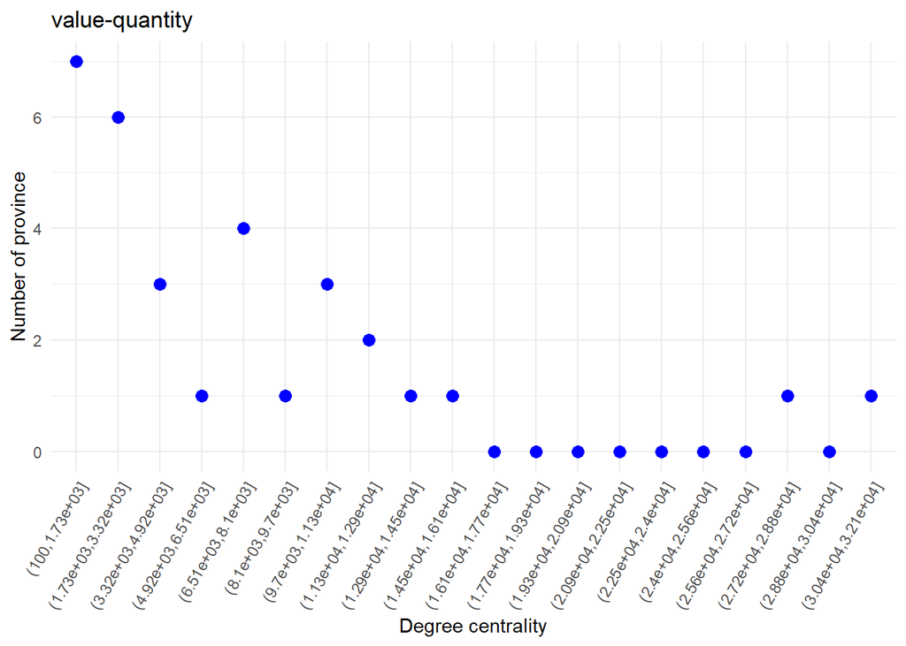

```r
degree_centr <- centralities$degree
count <- as.data.frame(table(cut(degree_centr, breaks = 20)))

ggplot(count, aes(x = Var1 , y = Freq)) +
  geom_point(color = "blue", size = 3) +
  labs(title = "value-quantity", x = "Degree centrality", y = "Number of province") +
  theme_minimal() +
  scale_x_discrete() +
  theme(axis.text.x = element_text(angle = 60, hjust = 1))
```

After dividing all the value of degree centrality equally into 20 groups and counting the number of provinces in each group, we can find that the distribution of the degree centrality has an obvious long-tail characteristics, which means that the degree centrality of most provinces is very small, while that of a small number of provinces is relatively large, showing a serious heterogeneity. Therefore, the labor migration network is scale-free.

With the codes below, we can rank the province nodes according to different centrality in each column and build a visual table.

```r
ranks <- centralities %>%
  mutate_at(vars(in_degree:pagerank_degree), funs(dense_rank(desc(.))))
ranks %>% kable(caption = "Rank") %>%
  scroll_box(width = "100%", height = "300px")
```

Rank

| names | in_degree | out_degree | in_out_degree_difference | degree | eigen_degree | pagerank_degree |
| --- | --- | --- | --- | --- | --- | --- |
| anhui | 26 | 1 | 31 | 3 | 3 | 21 |
| beijing | 5 | 30 | 4 | 9 | 16 | 5 |
| chongqin | 11 | 9 | 21 | 15 | 14 | 11 |
| fujian | 6 | 13 | 8 | 13 | 13 | 7 |
| gansu | 22 | 18 | 18 | 23 | 20 | 20 |
| guangdong | 1 | 23 | 1 | 1 | 1 | 4 |
| guangxi | 19 | 7 | 25 | 14 | 9 | 10 |
| guizhou | 8 | 8 | 22 | 12 | 12 | 8 |
| hainan | 17 | 25 | 9 | 28 | 25 | 9 |
| hebei | 15 | 10 | 23 | 16 | 19 | 13 |
| heilongjiang | 28 | 15 | 20 | 20 | 21 | 27 |
| henan | 24 | 2 | 30 | 6 | 7 | 22 |
| hubei | 21 | 6 | 26 | 11 | 11 | 23 |
| hunan | 18 | 3 | 29 | 7 | 4 | 19 |
| jiangsu | 4 | 12 | 5 | 4 | 5 | 3 |
| jiangxi | 31 | 5 | 27 | 10 | 8 | 26 |
| jilin | 27 | 20 | 16 | 27 | 27 | 28 |
| liaoning | 13 | 21 | 13 | 25 | 26 | 16 |
| neimenggu | 12 | 22 | 10 | 26 | 28 | 18 |
| ningxia | 30 | 26 | 14 | 30 | 30 | 30 |
| qinghai | 25 | 27 | 12 | 29 | 29 | 29 |
| shan1xi | 14 | 19 | 15 | 22 | 23 | 17 |
| shan3xi | 20 | 16 | 19 | 19 | 18 | 24 |
| shandong | 23 | 11 | 24 | 17 | 17 | 25 |
| shanghai | 3 | 29 | 3 | 5 | 10 | 1 |
| sichuan | 16 | 4 | 28 | 8 | 6 | 12 |
| tianjin | 7 | 24 | 6 | 21 | 24 | 6 |
| xinjiang | 9 | 28 | 7 | 24 | 22 | 14 |
| xizang | 29 | 31 | 11 | 31 | 31 | 31 |
| yunnan | 10 | 14 | 17 | 18 | 15 | 15 |
| zhejiang | 2 | 17 | 2 | 2 | 2 | 2 |

By combining the above characteristics with the research background, it’s clear that Guangdong Province is the largest province of labor inflow, which plays a decisive role in making this region the most influential province in the labor migration network. What’s more, Guangdong Province has more labor flows with other provinces with large labor mobility scale. In contrast, the Tibet Autonomous Region (Xizang) has the weakest influence in the labor migration network and its indirect influence is weak. In addition to these two provinces, Anhui Province is the largest province of labor outflow in China, but has little labor inflow. Shanghai not only has frequent labor migration with other provinces, but the provinces which it has labor mobility with are mostly provinces with large labor mobility, in other words, key nodes in the network.

It should be noted that the main reason for labor migration is to search for employment opportunities, higher salaries, better living conditions and etc. The huge differences between regions of China on development levels and labor force population have strongly promoted the mobility of China’s labor force population. The ranking of Guangdong, Anhui and Xizang are extreme, but also the reflection of their different regional geographical characteristics. Guangdong is the province with the highest GDP in China and has stable economic growth. The local industrial structure supported by manufacturing has a huge demand for labor and low requirements for labor quality. Anhui is located in the Yangtze River Delta Economic Zone and is close to economically developed provinces such as Jiangsu, Zhejiang, and Hubei. What’s more, as a populous province, Anhui has abundant labor resources. However, its own relatively low economic development level makes it less competitive in this region on attracting labor population, leading to a continuous large-scale labor population outflow. Xizang locates in western part of China, results in a huge travelling cost between those economically developed provinces. Although the government has strongly promoted infrastructure construction, it has not been able to make up for the shortcomings of poor transportation conditions caused by topography. Moreover, as an autonomous region for ethnic minorities, Xizang has formed a more conservative tendency to live a self-sufficient life from its strong local and ethnic culture, and the low economic development level shows little attraction to labor from other provinces.

## Community detection

The function `as.undirected` in the following codes will convert the directed network into a undirected one, in order to fit in the demands of the function `cluster_fast_greedy` we use for community detection, which can be regarded as the fast and greedy algorithm.

```r
net_undirected <- as.undirected(net_directed, mode = c("mutual"), edge.attr.comb = igraph_opt("edge.attr.comb"))
community_net1 <- cluster_fast_greedy(net_undirected)
community_net1
```

```
## IGRAPH clustering fast greedy, groups: 3, mod: 0.27
## + groups:
##   $`1`
##    [1] "chongqin"  "fujian"    "guangdong" "guangxi"   "hainan"    "hubei"
##    [7] "hunan"     "sichuan"   "xizang"    "yunnan"
##
##   $`2`
##    [1] "beijing"      "gansu"        "hebei"        "heilongjiang"
##    [5] "jilin"        "liaoning"     "neimenggu"    "ningxia"
##    [9] "qinghai"      "shan1xi"      "shan3xi"      "shandong"
##   [13] "tianjin"      "xinjiang"
##
##   + ... omitted several groups/vertices
```

After dividing all provinces into different community groups, we can now convert the object `community_net` into a dataframe. Then the community groups result can be mapped.

```r
community_net_map1 <- membership(community_net1) %>%
  unclass %>%
  as.data.frame %>%
  rename(community = ".") %>%
  rownames_to_column("name") %>%
  glimpse()
```

```
## Rows: 31
## Columns: 2
## $ name      <chr> "anhui", "beijing", "chongqin", "fujian", "gansu", "guangdon…
## $ community <dbl> 3, 2, 1, 1, 2, 1, 1, 3, 1, 2, 2, 3, 1, 1, 3, 3, 2, 2, 2, 2, …
```

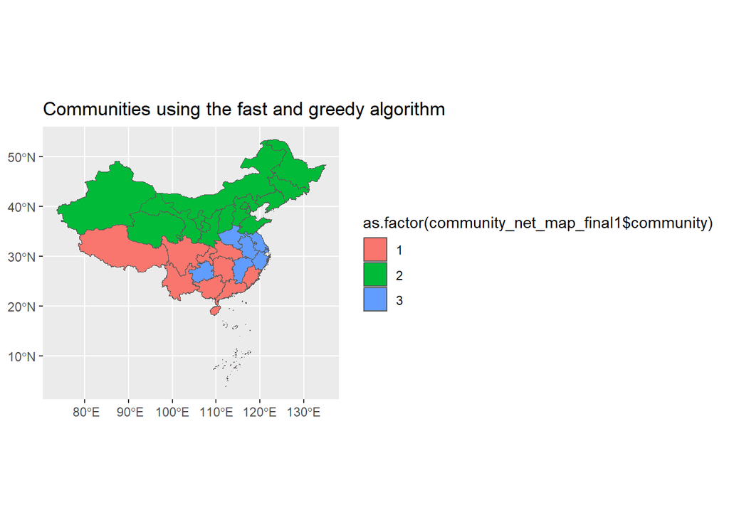

```r
community_net_map_final1 <- merge(basemap_multipolygon, community_net_map1, by = "name")

ggplot(community_net_map_final1$geometry, aes(fill = as.factor(community_net_map_final1$community))) +
  geom_sf() +
  ggtitle("Communities using the fast and greedy algorithm")
```

Similarly, we can use the leading eigenvector algorithm to perform community detection. This algorithm identifies communities by calculating the eigenvectors of the Laplacian matrix or similarity matrix of the graph, and is suitable for dense networks.

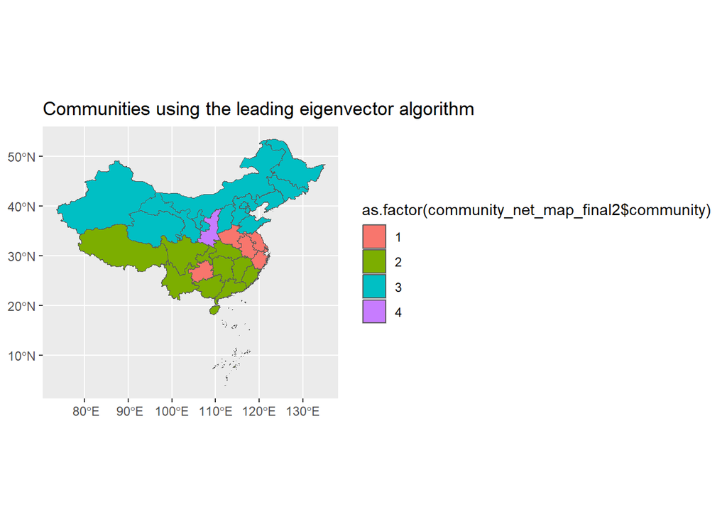

```r
community_net2 <- cluster_leading_eigen(net_undirected)

community_net_map2 <- membership(community_net2) %>%
  unclass %>%
  as.data.frame %>%
  rename(community = ".") %>%
  rownames_to_column("name")

community_net_map_final2 <- merge(basemap_multipolygon, community_net_map2, by = "name")

ggplot(community_net_map_final2$geometry, aes(fill = as.factor(community_net_map_final2$community))) +
  geom_sf() +
  ggtitle("Communities using the leading eigenvector algorithm")
```

Comparing to the fast and greedy algorithm, the leading eigenvector algorithm produces an isolated small community, making its quality of community detection in this labor flow network worse. Therefore, we should take the first output map to analyze.

As the map shows, the provinces are divided into three communities. Except Guizhou, the first community basically covers all provinces in southwestern China. As the community with most provinces, the second community lays in the northern part of China. The third community, which is the smallest one, locates in the southeastern China.

## Conclusion

Based on the data from China Migrants Dynamic Survey (CMDS) in 2017, this paper uses RStudio to build up China’s inter-provincial labor migration network. In addition to drawing an interactive map with optional departure provinces and flow levels, I also analyze the topological structure of the network and conducts community detection. The results are as follows.

Secondly, the scale of China’s labor population migration shows significant difference in space, that is, larger in the east and smaller in the west, which is basically consistent with China’s population distribution. Comparing to the middle and western part of China, China’s eastern coastal areas have flatter terrain, more convenient transportation, and more developed economy, which has led to a larger scale of labor population flowing to this region.

Thirdly, Chinese provinces can be divided into three categories according to the difference in the in-and-out degree of node centrality, which are provinces with net outflow of population, provinces with net inflow of population and provinces with balanced population flow. The root cause for the formation of the first two categories’ labor population flow characteristics is the huge difference in regional economic development levels. However, as for the provinces with balanced population flow, it is the result of combined influence of the economic development level and the migration concept under regional culture.

Fourthly, the community detection by the fast and greedy algorithm is applied to China’s labor population migration network, and the network is divided into three communities locate in northern, southwestern and southeastern China. These geographical blocks composed of neighboring provinces are the intuitive reflection of the fact that geographical proximity is the main factor which effects labor population migration. The phenomenon that Guizhou, which belongs to the southeastern community, surrounded by southwestern community as an enclave, reflects the impact of policy factors on China’s labor population migration.

```
                                                                                    Words: 3466
```

## Reference

[1] Xianghua Lin. Study on the spatial distribution and changes of the labor force population in Guangdong Province[J].Population and Development, 2003, 009(005):29-38.DOI:CNKI:SUN:SCRK.0.2003-05-004.

[2] Chenxin Liu, Kangjie Zhao. Study on the network structure and influencing factors of inter-provincial population mobility in China[J].Productivity research, 2024(7):19-24.

[3] Lucang Wang, Danxia Zhao, Yunxian Yang. Study on the spatiotemporal heterogeneity of floating population within the urban agglomeration in the upper reaches of the Yellow River[J].China West, 2022(1):27-35.

[4] Gale D, Johnson. Provincial Migration in Chinainthe 1990s [J].China Economic Review, 2003, 14(1):22-23

[5] Shang Dong, Yingxia Pu, Jingsong Ma, etc.. A complex network study of inter-provincial population migration in China[J].Southern Population, 2014, 29(2):8.DOI:10.3969/j.issn.1004-1613.2014.02.007.

[6] Xumeng Xiang, You Zhou, Qian Zhao. Study on the spatial structure of provincial population mobility from the perspective of youth migration: A case study of Shandong Province[A]. China Urban Planning Society. People’s City, Planning Empowerment - Proceedings of the 2023 China Urban Planning Annual Conference (14 Regional Planning and Urban Economy)[C].Urban Planning Society of China: Urban Planning Society of China,2023:14.DOI:10.26914/c.cnkihy.2023.061542.